# Assignment 3

Vishal

2022-10-12

```r
library(tidyverse)
```

```r
library(ggplot2)
library(Stat2Data)
data("Hawks")
```

# 1. Exploratory data analysis

## 1.1 (Q1)

```r
HawksTail <- Hawks$Tail
HawksTail[1:6]
```

```
## [1] 219 221 235 220 157 230
```

```r
mean(HawksTail)
```

```
## [1] 198.8315
```

```r
median(HawksTail)
```

```
## [1] 214
```

## 1.2 (Q1)

```r
Hawks %>%
  summarise_at(vars(Wing:Weight), c(mean, median), na.rm = T)
```

```
##   Wing_fn1 Weight_fn1 Wing_fn2 Weight_fn2
## 1 315.6375   772.0802      370        970
```

```r
Hawks %>%
  summarise(Wing_mean = mean(Wing, na.rm = T),
            Wing_t_mean = mean(Wing, trim = 0.5, na.rm = T),
            Wing_med = median(Wing, na.rm = T),
            Weight_mean = mean(Weight, na.rm = T),
            Weight_t_mean = mean(Weight, trim = 0.5, na.rm = T),
            Weight_med = median(Weight, na.rm = T))
```

```
##   Wing_mean Wing_t_mean Wing_med Weight_mean Weight_t_mean Weight_med
## 1  315.6375         370      370    772.0802           970        970
```

We are calculating mean of 50% trimmed data which essentially means that we are setting aside the top and bottom half and are leaving only a single value in the middle. Which is a median value and that’s why mean and median are same when we take a mean with trim value of 0.5.

## 1.2 (Q2)

```r
Hawks %>%
  group_by(Species) %>%
  summarise(Wing_mean = mean(Wing, na.rm = T),
            Wing_t_mean = mean(Wing, trim = 0.5, na.rm = T),
            Wing_med = median(Wing, na.rm = T),
            Weight_mean = mean(Weight, na.rm = T),
            Weight_t_mean = mean(Weight, trim = 0.5, na.rm = T),
            Weight_med = median(Weight, na.rm = T))
```

```
## # A tibble: 3 × 7
##   Species Wing_mean Wing_t_mean Wing_med Weight_mean Weight_t_mean Weight_med
##   <fct>       <dbl>       <dbl>    <dbl>       <dbl>         <dbl>      <dbl>
## 1 CH           244.         240      240        420.          378.       378.
## 2 RT           383.         384      384       1094.         1070       1070
## 3 SS           185.         191      191        148.          155        155
```

## 1.3 (Q1)

```r
X = c(1, 2, 3, 4, 5, 6, 7, 8, 9, 10)
A = mean(X)

a = 2
b = 3
X_ = (a * X) + b
A_ = mean(X_)

A
```

```
## [1] 5.5
```

```r
A_
```

```
## [1] 14
```

The mean of `X_` can be defined by `A_ = a * A + b`. That means, we can get the mean of newer vector by multiplying the mean of older vector by value of `a` and adding the value of `b` to the the result.

```r
HawksTailMean = mean(HawksTail)
HawksTail_ = (HawksTail * a) + b
HawksTail_Mean = mean(HawksTail_)

HawksTailMean
```

```
## [1] 198.8315
```

```r
HawksTail_Mean
```

```
## [1] 400.663
```

Hence, it is proved that `A_ = a * A + b`.

## 1.3 (Q2)

```r
X = c(1, 2, 3, 4, 5, 6, 7, 8, 9, 10)
varX = var(X)
sdX = sd(X)

a = 4
b = 3

X_ = (a * X) + b
varX_ = var(X_)
sdX_ = sd(X_)

varX
```

```
## [1] 9.166667
```

```r
sdX
```

```
## [1] 3.02765
```

```r
varX_
```

```
## [1] 146.6667
```

```r
sdX_
```

```
## [1] 12.1106
```

It is seen that variance of a newer vector is square times the value of `a`. Whereas the value of standard deviation of the newer vector is `a` times the value of standard deviation of older vector.

```r
varHawksTail = var(HawksTail)
sdHawksTail = sd(HawksTail)

a = 2
b = 3
HawksTail_ = (HawksTail * a) + b
varHawksTail_ = var(HawksTail_)
sdHawksTail_ = sd(HawksTail_)

varHawksTail
```

```
## [1] 1356.037
```

```r
sdHawksTail
```

```
## [1] 36.8244
```

```r
varHawksTail_
```

```
## [1] 5424.147
```

```r
sdHawksTail_
```

```
## [1] 73.64881
```

## 1.4 (Q1)

```r
hal <- Hawks$Hallux
hal <- hal[!is.na(hal)]
```

```r
outlier_val <- 100
num_outliers <- 10
corrupted_hal <- c(hal,rep(outlier_val,times=num_outliers))
```

```r
mean(hal)
```

```
## [1] 26.41086
```

```r
mean(corrupted_hal)
```

```
## [1] 27.21776
```

```r
num_outliers_vect <- seq(0, 1000)
means_vect <- c()
for(num_outliers in num_outliers_vect){
  corrupted_hal <- c(hal,rep(outlier_val, times = num_outliers))
  means_vect <- c(means_vect, mean(corrupted_hal))
}
```

Sample Median

```r
num_outliers_vect <- seq(0, 1000)
medians_vect <- c()
for(num_outliers in num_outliers_vect) {
  corrupted_hal <- c(hal, rep(outlier_val, times = num_outliers))
  medians_vect <- c(medians_vect, median(corrupted_hal))
}
```

## 1.4 (Q2)

Sample trimmed mean

```r
num_outliers_vect <- seq(0, 1000)
t_means_vect <- c()
for(num_outliers in num_outliers_vect){
  corrupted_hal <- c(hal,rep(outlier_val, times = num_outliers))
  t_means_vect <- c(t_means_vect, mean(corrupted_hal, trim = 0.1))
}
```

## 1.4 (Q3)

```r
df_means_medians <- data.frame(num_outliers = num_outliers_vect, mean = means_vect,
                               t_mean = t_means_vect, median = medians_vect)
```

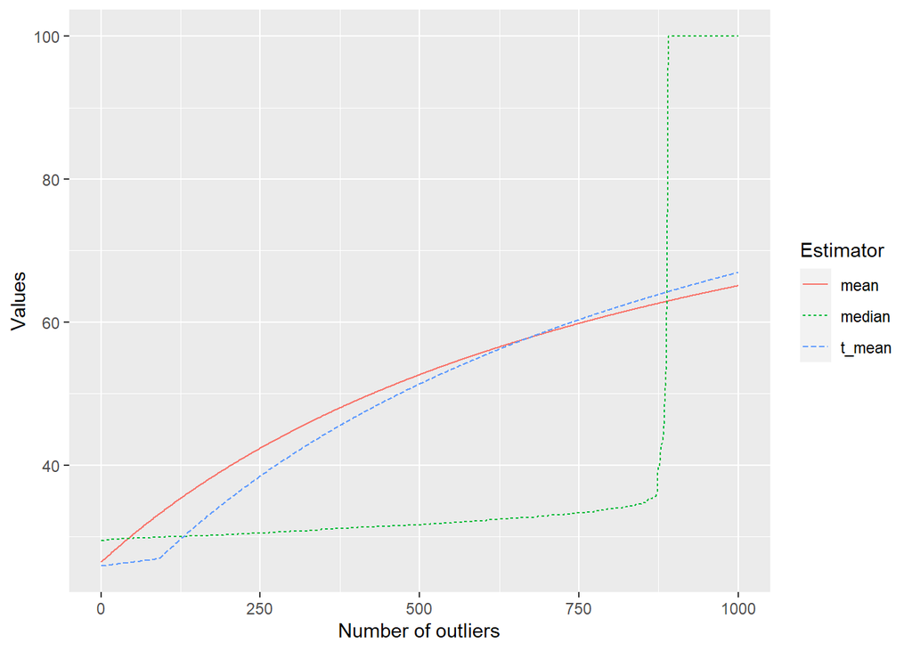

```r
df_means_medians %>%
  pivot_longer(!num_outliers, names_to = "Estimator", values_to = "Values") %>%
  ggplot(aes(x = num_outliers, color = Estimator, linetype = Estimator, y = Values)) +
  geom_line() +
  xlab("Number of outliers")
```

## 1.5 (Q1)

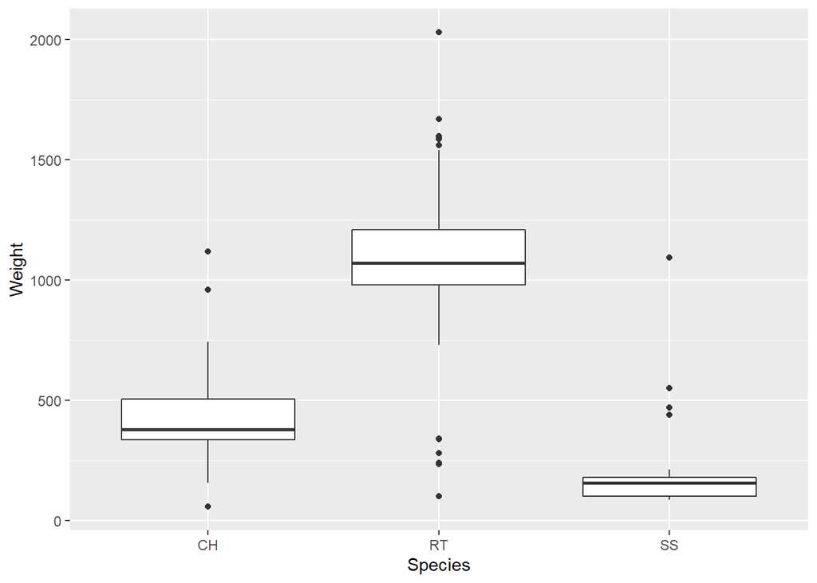

```r
Hawks %>%
  group_by(Species) %>%
  ggplot(aes(x = Species, y = Weight)) +
  geom_boxplot()
```

## 1.5 (Q2)

```r
q = c(.25, .50, .75)

Hawks %>%
  group_by(Species) %>%
  summarise(quantile025 = quantile(Weight, probs = q[1], na.rm = T),
            quantile050 = quantile(Weight, probs = q[2], na.rm = T),
            qunatile075 = quantile(Weight, probs = q[3], na.rm = T))
```

```
## # A tibble: 3 × 4
##   Species quantile025 quantile050 qunatile075
##   <fct>         <dbl>       <dbl>       <dbl>
## 1 CH              335        378.        505
## 2 RT              980       1070        1210
## 3 SS              100        155         178.
```

## 1.5 (Q3)

```r
num_outliers <- function(x) {

  x<-x[!is.na(x)]

  OutliersCount = 0
  q25 = quantile(x, probs = 0.25, na.rm = T)
  q75 = quantile(x, probs = 0.75, na.rm = T)

  IQR = q75 - q25


  for (i in x) {
    if ((i < q25 - (1.5 * IQR)) || (i > q75 + (1.5 * IQR))) {
      OutliersCount = OutliersCount + 1
    }
  }
  return(OutliersCount)
}
num_outliers( c(0, 40,60,185))
```

```
## [1] 1
```

## 1.5 (Q4)

```r
Hawks %>%
  group_by(Species) %>%
  summarise(num_outliers_weight = num_outliers(Weight))
```

```
## # A tibble: 3 × 2
##   Species num_outliers_weight
##   <fct>                 <dbl>
## 1 CH                        3
## 2 RT                       13
## 3 SS                        4
```

## 1.6 (Q1)

```r
covWeightWing <- cov(Hawks$Weight, Hawks$Wing, use = "complete.obs")
corrWeightWing <- cor(Hawks$Weight, Hawks$Wing, use = "complete.obs")

covWeightWing
```

```
## [1] 41174.39
```

```r
corrWeightWing
```

```
## [1] 0.9348575
```

## 1.6 (Q2)

```r
X <- seq(1, 10, by = 1)
Y <- seq(3, 5.7, by = 0.3)
Y
```

```
##  [1] 3.0 3.3 3.6 3.9 4.2 4.5 4.8 5.1 5.4 5.7
```

```r
S <- cov(X, Y)
R <- cor(X, Y)

a = 2
b = 3
c = 5
d = 4
X_ = (a * X) + b
Y_ = (c * Y) + d

S_ = cov(X_, Y_)
R_ = cor(X_, Y_)

S
```

```
## [1] 2.75
```

```r
R
```

```
## [1] 1
```

```r
S_
```

```
## [1] 27.5
```

```r
R_
```

```
## [1] 1
```

The covariance of a newer vector is `a * c` the value of covariance of a older vector. That means `S_ = S * a * c`. Whereas, the correlation stays the same although it becomes negative based on the signs of a and c.

```r
a = 2.4
b = 7.1
c = -1
d = 3

X = Hawks$Weight
Y = Hawks$Wing

S = cov(X, Y, use = "complete.obs")
R = cor(X, Y, use = "complete.obs")

X_ = (a * X) + b
Y_ = (c * Y) + d

S_ = cov(X_, Y_, use = "complete.obs")
R_ = cor(X_, Y_, use = "complete.obs")

S
```

```
## [1] 41174.39
```

```r
R
```

```
## [1] 0.9348575
```

```r
S_
```

```
## [1] -98818.54
```

```r
R_
```

```
## [1] -0.9348575
```

# 2. Random experiments, events and sample spaces, and the set theory

## 2.1 (Q1)

- **Random Experiment:** A random experiment is a procedure (real or imagined) which:
1. has a well-defined set of possible outcomes;
2. could (at least in principle) be repeated arbitrarily many times.
- **Event:** An event is a set (i.e. a collection) of possible outcomes of an experiment.
- **Sample space:** A sample space is the set of all possible outcomes of interest for a random experiment

## 2.1 (Q2)

**Event:** One or few of {1, 2, 3, 4, 5, 6}.  
**Sample space:** The whole set of {1, 2, 3, 4, 5, 6}  
**Number of different events:** {1}, {2}, {3}, {4}, {5}, {6} (In case of rolling a single dice! - 6 different events) Empty set is considered as an event. It is an impossible event.

## 2.2 (Q1)

1. $A \cup B = \{1, 2, 3, 4, 6\}$  
   $A \cup C = \{1, 2, 3, 4, 5, 6\}$
2. $A \cap B = \{2\}$  
   $A \cap C = \{\}$
3. $A \setminus B = \{1, 3\}$  
   $A \setminus C = \{1, 2, 3\}$
4. A and B are not disjoint. A and C are disjoint.
5. Yes, $B$ and $A \setminus B$ are disjoint.
6. $\{1, 2, 3\}, \{4, 5, 6\}$  
   $\{1, 2\}, \{3, 4\}, \{5,6\}$

## 2.2 (Q3)

$n(\Omega) = n(w_1) + n(w_2) + ... + n(w_k)$

## 2.2 (Q4)

If any of the set is $\emptyset$ then it is disjoint from every other set and also other conditions hold true in that case. $A \cap B = \emptyset$ for all $B \subset \Omega$.

## 2.2 (Q5)

1. $1_A`(x) = 1 - 1_A(x)$
2. Yes, $B = \Omega - A$ or $A \cap B = \emptyset$
3. $1 - 1_{A\cup B} = (1 - 1_A)(1 - 1_B)$  
   i.e. $(A \cap B)^\complement = A^\complement \cup B^\complement$

# 3. Visualisation

## 3 (Q1)

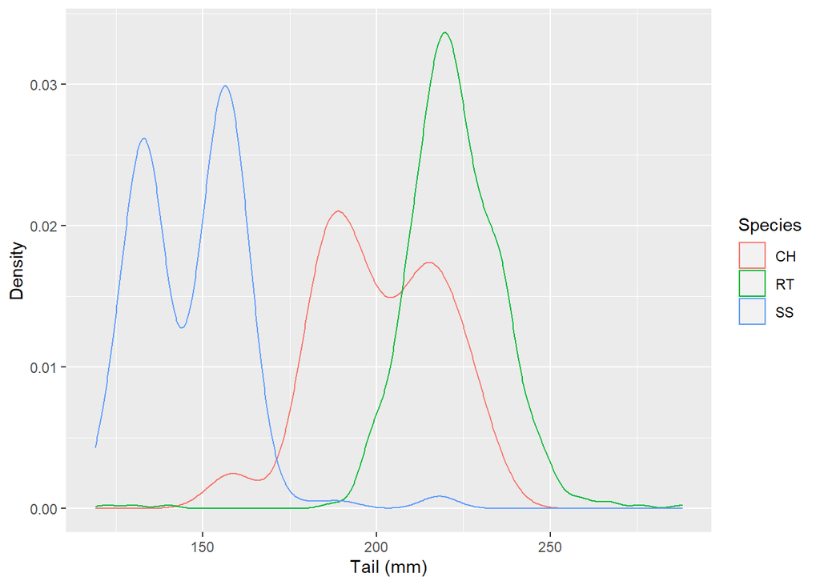

```r
Hawks %>%
  group_by(Species) %>%
  ggplot(aes(x = Tail, color = Species)) +
  geom_density() +
  xlab("Tail (mm)") +
  ylab("Density")
```

## 3 (Q2)

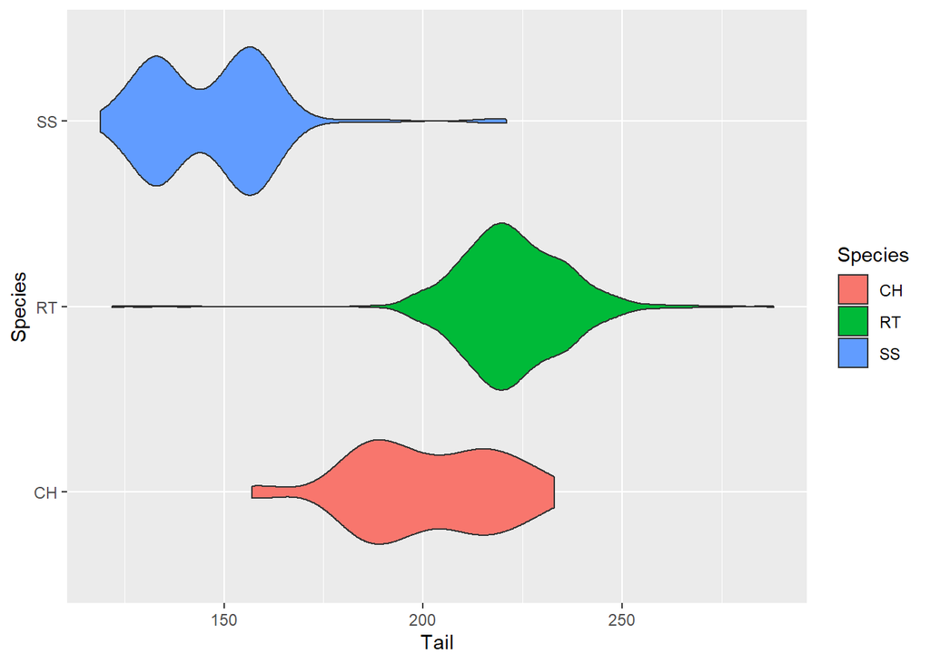

```r
Hawks %>%
  group_by(Species) %>%
  ggplot(aes(x = Tail, fill = Species, y = Species)) +
  geom_violin(stat = "ydensity")
```

## 3 (Q3)

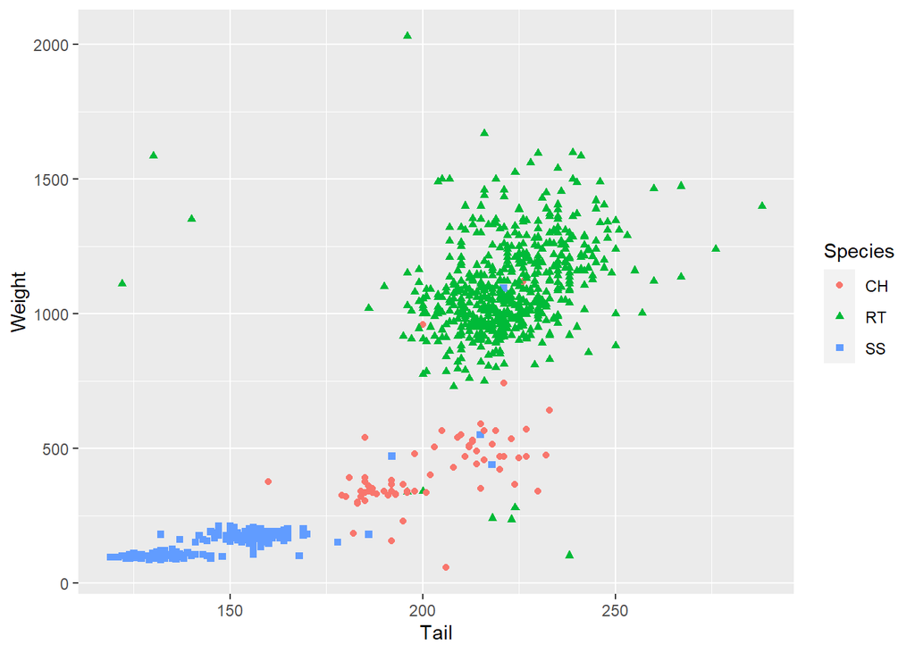

```r
Hawks %>%
  ggplot(aes(x = Tail, y = Weight, color = Species, shape = Species)) +
  geom_point()
```

## 3 (Q4)

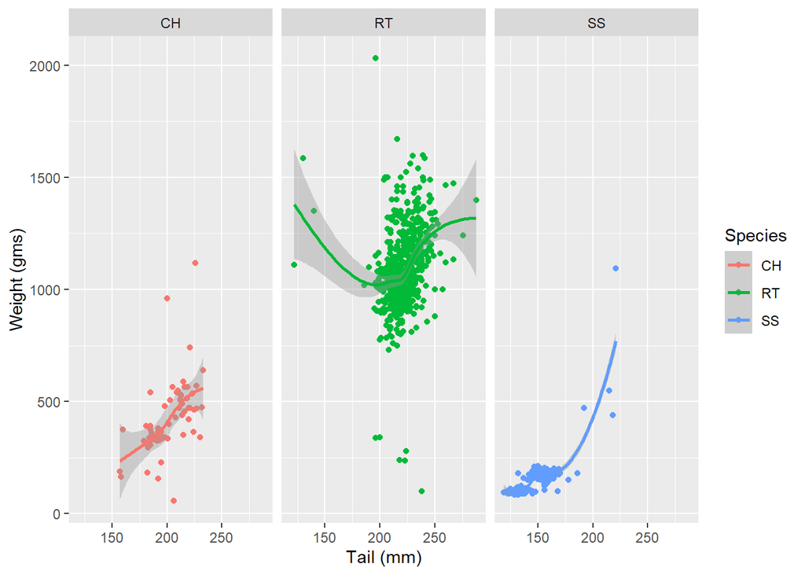

```r
Hawks %>%
  ggplot(aes(x = Tail, y = Weight, color = Species)) +
  geom_point() +
  facet_wrap(vars(Species)) +
  geom_smooth() +
  xlab("Tail (mm)") +
  ylab("Weight (gms)")
```

## 3 (Q5)

```r
HeaviestHawk <- Hawks %>%
  top_n(1, Weight)
```

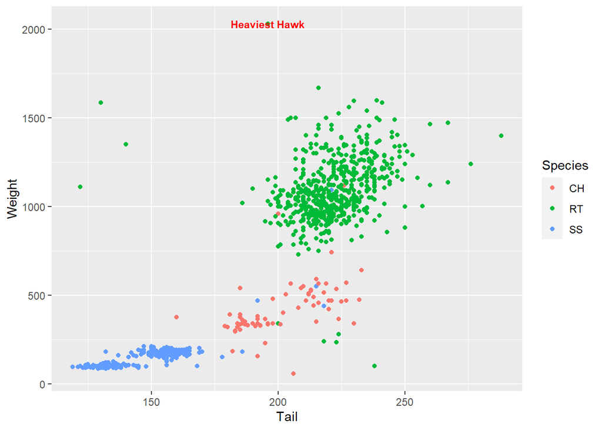

```r
annotation <- data.frame(
   x = HeaviestHawk$Tail,
   y = HeaviestHawk$Weight,
   label = c("Heaviest Hawk")
)


p <- Hawks %>%
  ggplot(aes(x = Tail, y = Weight, color = Species)) +
  geom_point()

p + geom_text(data = annotation, aes(x=x, y=y, label=label),                 ,
           color="red",
           size=3 , angle=0, fontface="bold" )
```

```r
#p + annotate("segment", x = annotation$x, xend = annotation$x, y = annotation$y-100, yend = #annotation$y, colour = "pink", size=1, alpha=0.6, arrow=arrow())
```